# o-well assignment # 3

Antonio Barber [antonio_barber]

```r
# github.monte
which.github = "local";  # local ... remote

github.local = "C:/_git_/github/abarber7/WSU_STATS419_2021/workspace/o-well";
github.remote = "https://raw.githubusercontent.com/abarber7/WSU_STATS419_2021/main";

if(which.github == "remote")
  {
  mypath = paste0(github.remote,"/workspace/")
  } else {
           mypath = paste0(github.remote,"/workspace/")
          }
```

# Read in the data

I will read in a list of dataframes from a RDS file. Then I will assign each dataframe to a variable.

```r
readInWells = readRDS(url("https://raw.githubusercontent.com/abarber7/WSU_STATS419_2021/main/workspace/o-well/wells.rds"))
owell.metals = readInWells[["wells$saudi$metals"]]
owell.chemistry = readInWells[["wells$saudi$chemistry"]]

print(owell.chemistry)
```

```
##     pH  Eh   TDS  Ca  K  Mg   Na HCO3   Cl  SO4 NO3   F PO4   TH  TA    TS   SS COD BOD  DO well  latitude longitude altitude.ft     fault.m                        geology
## 1  7.5 377  1780 269 19  75  338  226  852  302  42 1.1 0.4  977 185  3320 1540 0.4 1.1 6.7    1  28.63811 34.798061         257 1208.136649                           Sand
## 2  7.4 382  1456 259 20  68  257  183  710  312  41 1.0 0.1  925 150  2946 1490 0.2 1.4 6.5    2 28.603468 34.810458        1652 421.8996184        Sand, Alkaline, Granite
## 3  7.4 378  1471 476 35  66  238  189  710  797  40 1.1 0.1 1460 155  2976 1505 0.4 1.9 6.6    3 28.575879 34.844785         924 421.8996184         Alkaline, Conglomerate
## 4  7.5 382  1578 374 17  60  226  220  745  413  39 1.1 0.1 1180 180  3144 1566 0.8 1.5 6.7    4 28.620362 34.876969        1815 1509.433962                       Alkaline
## 5  7.7 376  1411 291  7  58  191  214  710  178  40 1.1 0.1  966 175  2906 1495   1 1.4 7.0    5 28.560586 34.990046        1408 421.8996184          Volcanic rock,Granite
## 6  7.8 380  1400 464  3  58  338  159  710  935  40 1.0 0.1 1400 130  2880 1480 0.4 1.9 6.1    6 28.602789 34.992551        2640 1555.888915                  Volcanic rock
## 7  7.6 374  1683 369 17  83  272  128  781  606  42 1.0 0.1 1261 105  3198 1515 0.8 0.4 6.0    7 28.488311 34.976893         956 1016.068832                         Gypsum
## 8  7.3 377  1184 330 10  42  132  128  568  341  42 1.0 0.1  998 105  2559 1375 1.2 1.5 7.0    8 28.572316 34.807835        1312 1132.075472                       Alkaline
## 9  7.5 370  1784 311 39  73  352  153  781  634   7 1.0 0.1 1078 125  3240 1456 0.4 1.9 7.5    9 28.438361 34.786616         595 1623.080239                         Gypsum
## 10 7.4 367  1319 316  8  59  447  134  639  925  45 1.0 0.1 1033 110  2820 1501   1 1.7 7.5   10 28.553648 34.903739        2291 1132.075472                  Volcanic rock
## 11 7.6 367   985 234 10  35  112  165  497  120  40 1.0 0.1  729 135  2317 1332 0.4 1.7 7.0   11 28.651337 34.876725        3168 377.3584906               Alkaline,Granite
## 12 7.6 386  1048 214  5  37  109  140  426  178  38 1.0 0.1  689 115  2488 1440 1.2 0.5 6.9   12 28.584441 35.186706        2307 1132.075472                        Granite
## 13 7.5 382  1878 399  6  72  267  165 1065  202  43 1.0 0.1 1293 135  3463 1585 0.4 1.7 6.8   13 28.512148 34.957213        1089 2109.498092                         Gypsum
## 14 7.4 380  3028 427 10 133  482  159 1562  298  48 1.0 0.1 1615 130  4758 1730 0.8 1.7 7.1   14 28.448275  34.93563         864 2005.687889                         Gypsum
## 15 7.4 378  2583 456 39  96  400  183 1349  350  46 0.9 0.1 1535 150  4253 1670   1 1.9 7.3   15 28.625897 35.051013        1494 1360.585387                  Volcanic rock
## 16 7.8 377  1124 262  4  38  109  153  568   92  39 0.9 0.1  812 125  2544 1420 0.4 1.9 7.0   16 28.612935 35.218209        2284 566.0377358 Alkaline,Granite,Volcanic rock
## 17 7.8 377   800 246 16  26   64  171  426  120  28 1.0 0.1  723 140  2122 1322 0.4 2.0 6.2   17  28.54015 35.065537        1167 943.3962264            Conglomerate,Gypsum
## 18 7.2 389  3080 506 24  27 1816  110 3408  408  47 0.8 0.1 1376  90  4838 1758 1.2 1.6 6.9   18 29.248557 35.017044        1032  3207.54717                           Sand
## 19 7.1 394  6703 461 24  29 2661  128 4686  331  46 0.8 0.1 1272 105  8835 2132 1.2 0.4 6.2   19 29.235329 34.969706         279 777.9444577                           Sand
## 20 7.0 387 10018 900 29  56 3879  116 7455  302  43 0.8 0.3 2478  95 12722 2704 1.2 1.5 6.9   20 29.291152 34.977884         403 754.7169811                           Sand
## 21 7.0 382  2142 290 20  21 1251  153 1349 1402  45 1.0 0.1  811 125  3762 1620 1.6 1.8 7.3   21 29.336922 34.981922         552 843.7992368                           Sand
## 22 7.1 388  5010 677 21  29 1639  110 3408  465  27 1.0 0.2 1810 140  6940 1930 1.2 1.1 6.7   22 29.319727 35.032035        1245 1886.792453                           Sand
## 23 7.6 355   406 239  5  12  207  159  213  612  44 1.0 0.1  646 130  1698 1292 1.2 1.9 7.3   23  29.24509 35.185575        2831 188.6792453               Alkaline,Granite
```

```r
print(owell.metals)
```

```
##     As    B    Ba  Be  Cd  Co  Cr  Cu   Fe   Hg  Mn Mo  Pb  Se  Zn well  latitude longitude altitude.ft     fault.m                        geology
## 1  0.2 15.2   7.1 0.3 0.3 0.1 0.5 0.6   93  0.5 0.1 26 2.2 1.5 0.8    1  28.63811 34.798061         257 1208.136649                           Sand
## 2  0.3  9.4   7.5 0.3 0.4 0.1 0.3 0.6   14 18.7 0.3 14 1.9 1.8 0.6    2 28.603468 34.810458        1652 421.8996184        Sand, Alkaline, Granite
## 3  0.7  9.6   7.1 0.3 0.3 0.2 0.1 0.7   23 58.3 0.1 17 2.2 0.7 0.5    3 28.575879 34.844785         924 421.8996184         Alkaline, Conglomerate
## 4  0.2  9.9   6.8 0.4 0.4 0.3 0.4 0.6  2.5  3.9 0.2 24 2.8 1.5 0.3    4 28.620362 34.876969        1815 1509.433962                       Alkaline
## 5  0.7  9.1   8.8 0.4 0.3 0.2 0.5 0.7  3.7   20 0.2 11 2.3 0.9 1.6    5 28.560586 34.990046        1408 421.8996184          Volcanic rock,Granite
## 6  0.3  9.3   8.7 0.4 0.3 0.1 0.3 0.5    2  3.2 0.2 27 2.2 0.7 3.6    6 28.602789 34.992551        2640 1555.888915                  Volcanic rock
## 7  0.3 18.5   9.2 0.4 0.3 0.1 0.6 0.5    4  2.3 0.1 13 2.5 2.3 1.6    7 28.488311 34.976893         956 1016.068832                         Gypsum
## 8  0.6    7  13.9 0.4 0.3 0.1 0.4 0.5  1.2 19.2 0.1 18 2.5 0.9 1.2    8 28.572316 34.807835        1312 1132.075472                       Alkaline
## 9  0.2  8.5   3.3 0.3 0.3 0.1 0.3 0.6  2.7  1.9 0.3 31   3 0.1 0.8    9 28.438361 34.786616         595 1623.080239                         Gypsum
## 10 0.1  8.6  24.6 0.4 0.3 0.2 0.8 0.5  0.8 21.7 0.1 25 2.1 1.5 1.4   10 28.553648 34.903739        2291 1132.075472                  Volcanic rock
## 11 0.7  6.6  17.4 0.3 0.3 0.2 0.4 0.5  1.6  4.3 0.2 18 2.1 1.5 0.5   11 28.651337 34.876725        3168 377.3584906               Alkaline,Granite
## 12 0.8    7  10.8 0.4 0.3 0.2 0.6 0.7  1.3    1 0.2 27 2.7 2.8 0.4   12 28.584441 35.186706        2307 1132.075472                        Granite
## 13 0.5    7  41.2 0.3 0.1 0.2 0.5 0.5  7.8  0.7 5.2 15 2.9 2.5 6.5   13 28.512148 34.957213        1089 2109.498092                         Gypsum
## 14 1.2 22.8  16.7 0.4 0.3 0.1 2.1 0.7  0.5  2.1 0.3 12 1.3 2.2 0.9   14 28.448275  34.93563         864 2005.687889                         Gypsum
## 15 2.2 16.4  20.2 0.4 0.3 0.1 0.7 0.6 14.9  0.1 0.7 13 1.7   3 0.4   15 28.625897 35.051013        1494 1360.585387                  Volcanic rock
## 16 0.4  6.6  43.1 0.5 0.3 0.7 0.7 0.5    2  1.2 0.8 23 2.3 2.3 0.1   16 28.612935 35.218209        2284 566.0377358 Alkaline,Granite,Volcanic rock
## 17   1  4.9  25.6 0.4 0.3 0.2 0.7 0.6  3.7  0.7 0.3 19 2.4 0.7 1.1   17  28.54015 35.065537        1167 943.3962264            Conglomerate,Gypsum
## 18 0.3 16.4  77.3 0.3 0.3 0.2 1.3 0.8  0.5  0.1 0.8 12 1.1 0.5 1.2   18 29.248557 35.017044        1032  3207.54717                           Sand
## 19 0.8 13.2  79.4 0.3 0.3 0.2 0.5 0.6  4.5 28.2 0.1 11 0.1 0.2   2   19 29.235329 34.969706         279 777.9444577                           Sand
## 20 1.5 16.7 100.8 0.2 0.3 0.2 0.4 0.6  0.6  1.8 0.3 22 0.7 0.2 2.1   20 29.291152 34.977884         403 754.7169811                           Sand
## 21 0.9  9.7  44.7 0.4 0.3 0.1   1 0.8  0.6 44.3 0.1 14 1.4 0.4 0.3   21 29.336922 34.981922         552 843.7992368                           Sand
## 22 0.1 12.8  68.5 0.4 0.3 0.1 0.8 0.9  0.7  3.5 0.1 21   2 0.4 3.9   22 29.319727 35.032035        1245 1886.792453                           Sand
## 23 0.5  4.4   9.1 0.5 0.3 0.1 1.4 0.6  0.2 10.1 0.1 21 1.9 0.2 3.4   23  29.24509 35.185575        2831 188.6792453               Alkaline,Granite
```

# Summary of Metals

This summary statistics of the metals table include: the median, the mean, the standard error on the mean (SE.mean), the confidence interval of the mean (CI.mean) at the p level (default is 0.95), the variance (var), the standard deviation (std.dev), and the variation coefficient (coef.var) defined as the standard deviation divided by the mean.

```r
library(pastecs)
metals = owell.metals[c(1:23), -c(21)]

dat <- as.data.frame(sapply(metals, as.numeric))

res <- stat.desc(dat[, -5])
round(res, 2)
```

|  | As | B | Ba | Be | Co | Cr | Cu | Fe | Hg | Mn | Mo | Pb | Se | Zn | well | latitude | longitude | altitude.ft | fault.m |
| --- | --- | --- | --- | --- | --- | --- | --- | --- | --- | --- | --- | --- | --- | --- | --- | --- | --- | --- | --- |
| nbr.val | 23.00 | 23.00 | 23.00 | 23.00 | 23.00 | 23.00 | 23.00 | 23.00 | 23.00 | 23.00 | 23.00 | 23.00 | 23.00 | 23.00 | 23.00 | 23.00 | 23.00 | 23.00 | 23.00 |
| nbr.null | 0.00 | 0.00 | 0.00 | 0.00 | 0.00 | 0.00 | 0.00 | 0.00 | 0.00 | 0.00 | 0.00 | 0.00 | 0.00 | 0.00 | 0.00 | 0.00 | 0.00 | 0.00 | 0.00 |
| nbr.na | 0.00 | 0.00 | 0.00 | 0.00 | 0.00 | 0.00 | 0.00 | 0.00 | 0.00 | 0.00 | 0.00 | 0.00 | 0.00 | 0.00 | 0.00 | 0.00 | 0.00 | 0.00 | 0.00 |
| min | 0.10 | 4.40 | 3.30 | 0.20 | 0.10 | 0.10 | 0.50 | 0.20 | 0.10 | 0.10 | 11.00 | 0.10 | 0.10 | 0.10 | 1.00 | 28.44 | 34.79 | 257.00 | 188.68 |
| max | 2.20 | 22.80 | 100.80 | 0.50 | 0.70 | 2.10 | 0.90 | 93.00 | 58.30 | 5.20 | 31.00 | 3.00 | 3.00 | 6.50 | 23.00 | 29.34 | 35.22 | 3168.00 | 3207.55 |
| range | 2.10 | 18.40 | 97.50 | 0.30 | 0.60 | 2.00 | 0.40 | 92.80 | 58.20 | 5.10 | 20.00 | 2.90 | 2.90 | 6.40 | 22.00 | 0.90 | 0.43 | 2911.00 | 3018.87 |
| sum | 14.50 | 249.60 | 651.80 | 8.40 | 4.10 | 15.30 | 14.20 | 185.80 | 247.80 | 10.90 | 434.00 | 46.30 | 28.80 | 35.20 | 276.00 | 661.31 | 804.24 | 32565.00 | 26596.58 |
| median | 0.50 | 9.40 | 16.70 | 0.40 | 0.20 | 0.50 | 0.60 | 2.00 | 3.20 | 0.20 | 18.00 | 2.20 | 0.90 | 1.10 | 12.00 | 28.60 | 34.98 | 1245.00 | 1132.08 |
| mean | 0.63 | 10.85 | 28.34 | 0.37 | 0.18 | 0.67 | 0.62 | 8.08 | 10.77 | 0.47 | 18.87 | 2.01 | 1.25 | 1.53 | 12.00 | 28.75 | 34.97 | 1415.87 | 1156.37 |
| SE.mean | 0.10 | 1.00 | 5.85 | 0.01 | 0.03 | 0.09 | 0.02 | 4.04 | 3.22 | 0.22 | 1.25 | 0.15 | 0.19 | 0.32 | 1.41 | 0.07 | 0.03 | 173.90 | 146.75 |

[output cut: 4 more lines]

# Summary of Chemistry

This summary statistics of the Chemistry table include: the median, the mean, the standard error on the mean (SE.mean), the confidence interval of the mean (CI.mean) at the p level (default is 0.95), the variance (var), the standard deviation (std.dev), and the variation coefficient (coef.var) defined as the standard deviation divided by the mean.

```r
library(pastecs)
chemistry = owell.chemistry[c(1:23), -c(26)]

dat2 <- as.data.frame(sapply(chemistry, as.numeric))

res <- stat.desc(dat2[, -5])
round(res, 2)
```

|  | pH | Eh | TDS | Ca | Mg | Na | HCO3 | Cl | SO4 | NO3 | F | PO4 | TH | TA | TS | SS | COD | BOD | DO | well | latitude | longitude | altitude.ft | fault.m |
| --- | --- | --- | --- | --- | --- | --- | --- | --- | --- | --- | --- | --- | --- | --- | --- | --- | --- | --- | --- | --- | --- | --- | --- | --- |
| nbr.val | 23.00 | 23.00 | 23.00 | 23.00 | 23.00 | 23.00 | 23.00 | 23.00 | 23.00 | 23.00 | 23.00 | 23.00 | 23.00 | 23.00 | 23.00 | 23.00 | 23.00 | 23.00 | 23.00 | 23.00 | 23.00 | 23.00 | 23.00 | 23.00 |
| nbr.null | 0.00 | 0.00 | 0.00 | 0.00 | 0.00 | 0.00 | 0.00 | 0.00 | 0.00 | 0.00 | 0.00 | 0.00 | 0.00 | 0.00 | 0.00 | 0.00 | 0.00 | 0.00 | 0.00 | 0.00 | 0.00 | 0.00 | 0.00 | 0.00 |
| nbr.na | 0.00 | 0.00 | 0.00 | 0.00 | 0.00 | 0.00 | 0.00 | 0.00 | 0.00 | 0.00 | 0.00 | 0.00 | 0.00 | 0.00 | 0.00 | 0.00 | 0.00 | 0.00 | 0.00 | 0.00 | 0.00 | 0.00 | 0.00 | 0.00 |
| min | 7.00 | 355.00 | 406.00 | 214.00 | 12.00 | 64.00 | 110.00 | 213.00 | 92.00 | 7.00 | 0.80 | 0.10 | 646.00 | 90.00 | 1698.00 | 1292.00 | 0.20 | 0.40 | 6.00 | 1.00 | 28.44 | 34.79 | 257.00 | 188.68 |
| max | 7.80 | 394.00 | 10018.00 | 900.00 | 133.00 | 3879.00 | 226.00 | 7455.00 | 1402.00 | 48.00 | 1.10 | 0.40 | 2478.00 | 185.00 | 12722.00 | 2704.00 | 1.60 | 2.00 | 7.50 | 23.00 | 29.34 | 35.22 | 3168.00 | 3207.55 |
| range | 0.80 | 39.00 | 9612.00 | 686.00 | 121.00 | 3815.00 | 116.00 | 7242.00 | 1310.00 | 41.00 | 0.30 | 0.30 | 1832.00 | 95.00 | 11024.00 | 1412.00 | 1.40 | 1.60 | 1.50 | 22.00 | 0.90 | 0.43 | 2911.00 | 3018.87 |
| sum | 171.20 | 8705.00 | 53871.00 | 8770.00 | 1253.00 | 15787.00 | 3646.00 | 33618.00 | 10323.00 | 912.00 | 22.60 | 2.90 | 27067.00 | 3035.00 | 90729.00 | 36858.00 | 18.80 | 34.40 | 157.20 | 276.00 | 661.31 | 804.24 | 32565.00 | 26596.58 |
| median | 7.50 | 378.00 | 1578.00 | 330.00 | 58.00 | 272.00 | 159.00 | 745.00 | 341.00 | 42.00 | 1.00 | 0.10 | 1078.00 | 130.00 | 3144.00 | 1505.00 | 0.80 | 1.70 | 6.90 | 12.00 | 28.60 | 34.98 | 1245.00 | 1132.08 |
| mean | 7.44 | 378.48 | 2342.22 | 381.30 | 54.48 | 686.39 | 158.52 | 1461.65 | 448.83 | 39.65 | 0.98 | 0.13 | 1176.83 | 131.96 | 3944.74 | 1602.52 | 0.82 | 1.50 | 6.83 | 12.00 | 28.75 | 34.97 | 1415.87 | 1156.37 |
| SE.mean | 0.05 | 1.75 | 455.19 | 33.29 | 5.81 | 200.01 | 6.91 | 358.59 | 66.72 | 1.83 | 0.02 | 0.02 | 89.10 | 5.36 | 518.95 | 64.42 | 0.08 | 0.10 | 0.09 | 1.41 | 0.07 | 0.03 | 173.90 | 146.75 |

[output cut: 4 more lines]

# Extracting data from the metal Tables

This graph shows the level of all the different metals in μg/L throughout all 23 wells.

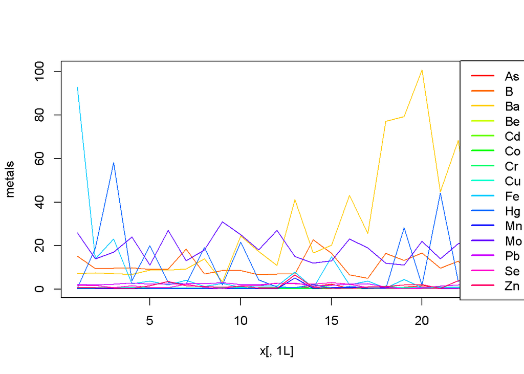

```r
library(pastecs)
metals = owell.metals[c(1:23), -c(16,17,18,19,20,21)]
mypalette = rainbow(ncol(metals))
matplot(y = metals, type = 'l', lty = 1, col = mypalette)
legend(legend = colnames(metals), x = 22.1, y = 105, lty = 1, lwd = 2, col = mypalette, xpd = TRUE, )
```

# Extracting data from the chemistry Tables

This graph shows the level of all the different chemicals in mg/L throughout all 23 wells.

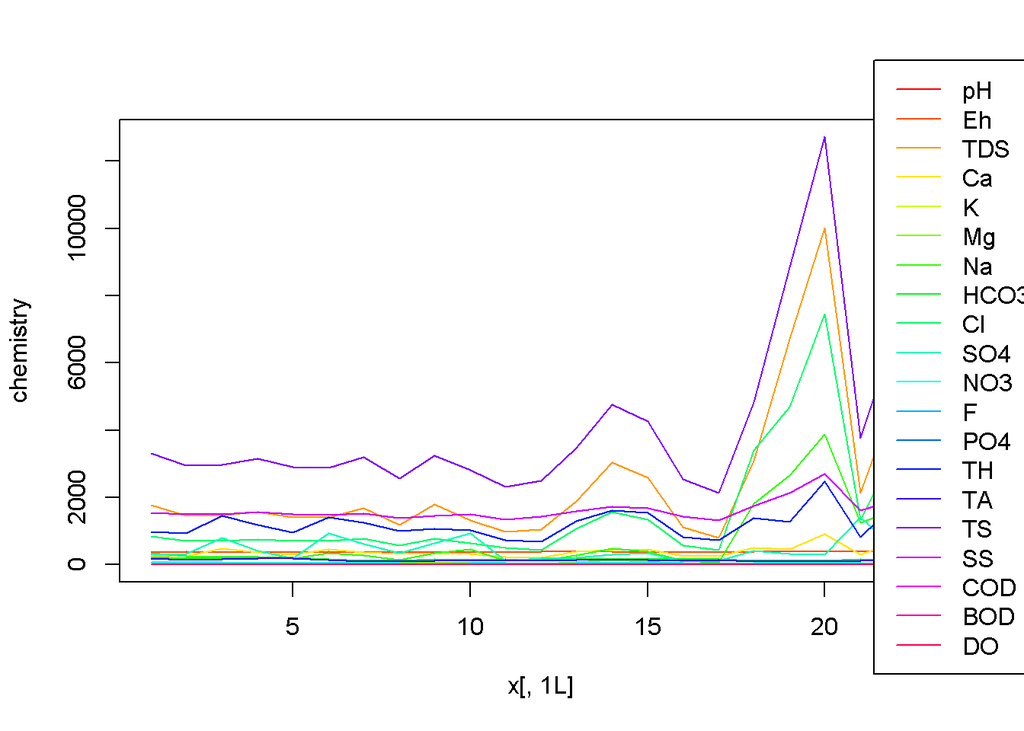

```r
library(pastecs)
chemistry = owell.chemistry[c(1:23), -c(21, 22, 23, 24, 25, 26)]
mypalette2 = rainbow(ncol(chemistry))

matplot(y = chemistry, type = 'l', lty = 1, col = mypalette2)
legend(legend = colnames(chemistry), x = 21.4, y = 15000, lty = 1, lwd = 1, col = mypalette2, xpd = TRUE)
```

# Boxplot of the metals

This graph is a boxplot that compares and displays the concentration levels of each of the metals in the 23 wells.

```r
library(ggpubr)
```

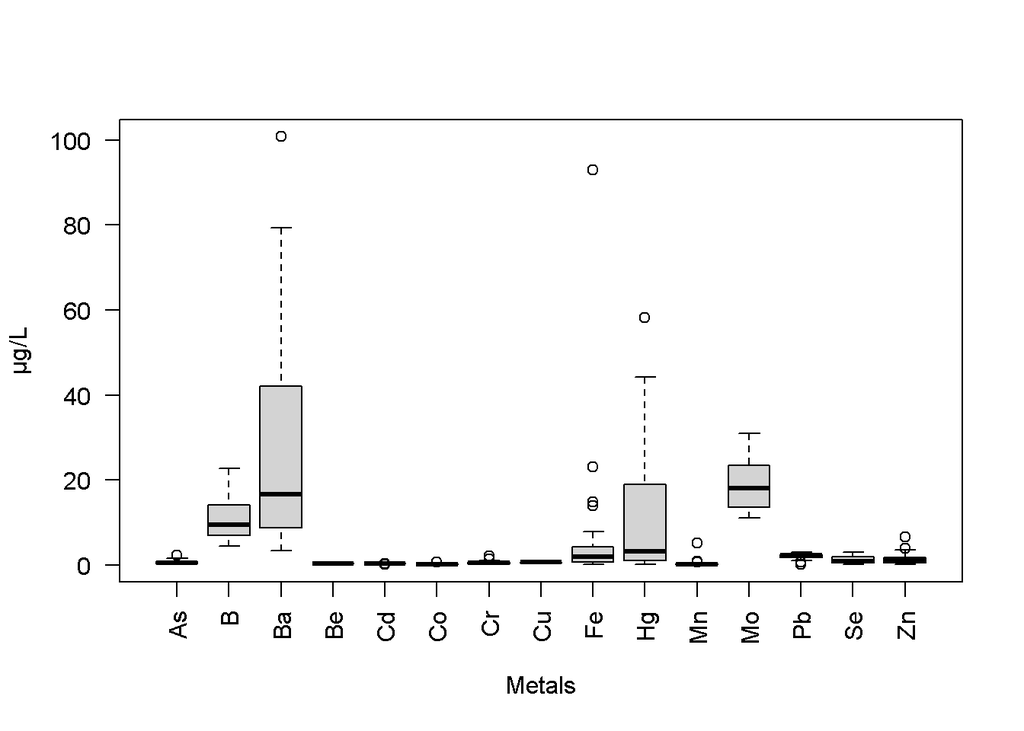

```r
metals = owell.metals[c(1:23), -c(16, 17,18,19,20,21)]
dat <- as.data.frame(sapply(metals, as.numeric))

boxplot(dat,xlab = "Metals", ylab = "μg/L", las =2,cex.names=.75)
```

# Boxplot of the chemicals

This graph is a boxplot that compares and displays the concentration levels of each of the chemicals in all of the wells.

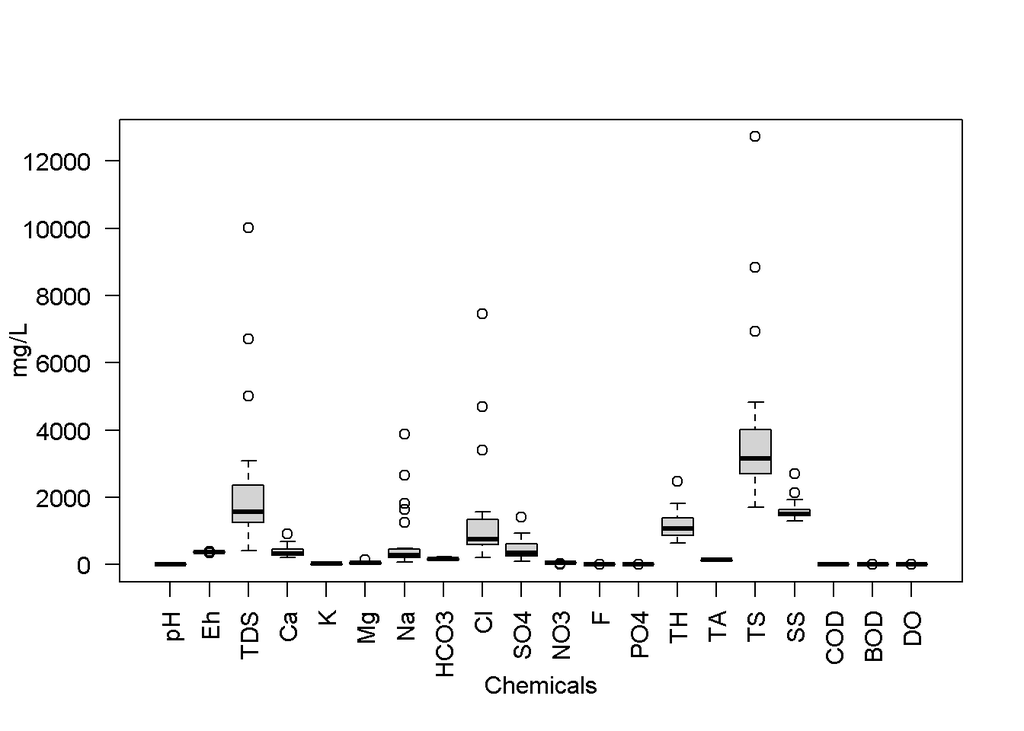

```r
chemistry = owell.chemistry[c(1:23), -c(21, 22, 23, 24, 25, 26)]
dat2 <- as.data.frame(sapply(chemistry, as.numeric))

boxplot(dat2,xlab = "Chemicals", ylab = "mg/L", las =2,cex.names=.75)
```